# Longitudinal_HW1_JYang

2024-09-18

# Load the data

```r
fev_data <- read.table("C:/Users/jyang/OneDrive - Arizona State University/10 Classes_OneDrive/2024 8F_STP598_Logitudinal/zz HW/Longitudinal_HW1/fevclongdat.txt", header = TRUE)
```

# Question 3.

Obtain a scatter plot (spaghetti plot) of subject trajectories across time. Based on this plot, does it seem reasonable to assume that there is not interaction between the subject factor and time? Why is this assumption important for testing the null hypothesis of no time effect?

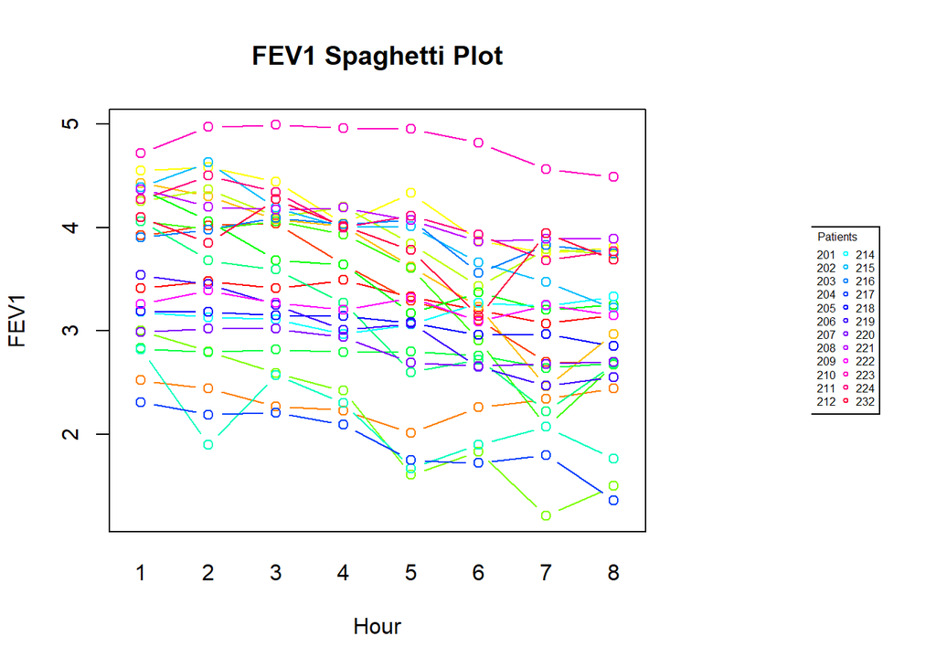

```r
num_patients <- length(unique(fev_data$patient))  # Number of unique patients
col <- rainbow(num_patients)  # Assign unique colors to each patient

layout(matrix(c(1, 2), ncol = 2), widths = c(3, 1))

interaction.plot(fev_data$hour, as.factor(fev_data$patient), fev_data$fev1,
                 xlab = "Hour",
                 ylab = "FEV1",
                 lty = 1,  # Solid lines
                 legend = FALSE,  # Suppress the legend
                 type = "b",  # Plot both lines and points
                 col = col,  # Use rainbow colors for each patient
                 pch = 1)  # Plotting symbol for all patients (can be customized)
title("FEV1 Spaghetti Plot")

# Add a legend with patient numbers in 2nd area
plot.new()
legend("right", legend = unique(fev_data$patient), col = col, pch = 1,
       title = "Patients", cex = 0.5, ncol = 2)
```

# Question 4.

Use mean squares from the ANOVA table to obtain estimates of σb^2 and σε^2.

```r
library(lme4)
fit <- lm(fev1 ~ as.factor(patient), data = fev_data)
fit
```

```
##
## Call:
## lm(formula = fev1 ~ as.factor(patient), data = fev_data)
##
## Coefficients:
##           (Intercept)  as.factor(patient)202  as.factor(patient)203
##               3.31750                0.10750               -1.00375
## as.factor(patient)204  as.factor(patient)205  as.factor(patient)206
##               0.32000                0.85375                0.64750
## as.factor(patient)207  as.factor(patient)208  as.factor(patient)209
##              -1.19750                0.09375                0.27500
## as.factor(patient)210  as.factor(patient)211  as.factor(patient)212
##              -0.55250               -0.21500               -1.19375
## as.factor(patient)214  as.factor(patient)215  as.factor(patient)216
##              -0.15625                0.62875                0.58375
## as.factor(patient)217  as.factor(patient)218  as.factor(patient)219
##              -1.38875               -0.25250               -0.31875
## as.factor(patient)220  as.factor(patient)221  as.factor(patient)222
##              -0.48000                0.76250               -0.07625
## as.factor(patient)223  as.factor(patient)224  as.factor(patient)232
##               1.49000                0.75750                0.53000
```

```r
anova(fit)
```

```
## Analysis of Variance Table
##
## Response: fev1
##                     Df Sum Sq Mean Sq F value    Pr(>F)
## as.factor(patient)  23 98.476  4.2816  27.544 < 2.2e-16 ***
## Residuals          168 26.115  0.1554
## ---
## Signif. codes:  0 '***' 0.001 '**' 0.01 '*' 0.05 '.' 0.1 ' ' 1
```

```r
MSB <- 4.2816
MSE <- 0.1554
nj <- length(unique(fev_data$hour))
sigma_b_sq <- (MSB-MSE)/nj
sigma_e_sq <- MSE
cat("** sigma_b_sq = (MSB - MSE) /nj = (", MSB, "-", MSE, ")/", nj, "=", sigma_b_sq, "\n")
```

```
## ** sigma_b_sq = (MSB - MSE) /nj = ( 4.2816 - 0.1554 )/ 8 = 0.515775
```

```r
cat("** sigma_e_sq = MSE =", sigma_e_sq, "\n")
```

```
## ** sigma_e_sq = MSE = 0.1554
```

## Question 5.

Obtain a two-sided 95% confidence interval for σb2. Hint: Use the Satterthwaite approximation.

Reference: ALSM chapter 25.The Satterthwaite procedure (Ref. 25.3) is a general procedure for constructing approximate confidence intervals for linear combinations of expected mean squares.

** sigma_b_sq = (MSB - MSE) /nj  
** sigma_e_sq = MSE ** sigma_u_sq = (1/n)MSB + (-1/n)MSE Confidence interval for sigma_u_sq: linear combination of MS ** L_hat = sigma^2_u ** df = {c1(MS.1)+ ….+ ch(MS.h)}^2 / [ {c1(MS.1)^2 /df1} + …+{c1(MS.h)^2 /dfh}] 95% CI, alpha=0.05

```r
alpha <- 0.05
r <- length(unique(fev_data$patient)) # num_patients
nj <- 8 # 8 repeat measure, 8 time points
df.B <- (r-1)
df.W <- (r*(nj-1))
s_u_sq <- (1/nj)*MSB + (-1/nj)*MSE

# df Satterthwaite approxomation
nominator <- (nj * s_u_sq)^2
denominator <- MSB^2/(r-1) + MSE^2/(r*(nj-1))
cat("nominator = (nj * s_u_sq)^2 = 8 x 0.515775", "\n")
```

```
## nominator = (nj * s_u_sq)^2 = 8 x 0.515775
```

```r
cat("denominator = MSB^2/(r-1) + MSE^2/(r*(nj-1)) = (4.2816)^2/(24-1) + (0.15548)^2/(24(8-1))", "\n")
```

```
## denominator = MSB^2/(r-1) + MSE^2/(r*(nj-1)) = (4.2816)^2/(24-1) + (0.15548)^2/(24(8-1))
```

```r
df.approx <- nominator / denominator
cat("s_u_sq =", s_u_sq, "\n")
```

```
## s_u_sq = 0.515775
```

```r
cat("df.approx = ", df.approx, "\n")
```

```
## df.approx =  21.35688
```

```r
# Calculate chi-square critical values
chi_sq_upper <- qchisq(alpha/2, df.approx, lower.tail = TRUE)
chi_sq_lower <- qchisq(1 - alpha/2, df.approx, lower.tail = TRUE)
cat("chi_sq_upper =", chi_sq_upper, "\n")
```

```
## chi_sq_upper = 10.5317
```

```r
cat("chi_sq_lower =", chi_sq_lower, "\n")
```

```
## chi_sq_lower = 35.94431
```

```r
# Calculate the lower and upper bounds of the confidence interval
lower_bound <- (df.approx * s_u_sq) / chi_sq_lower
upper_bound <- (df.approx * s_u_sq) / chi_sq_upper
cat("95% Confidence Interval for sigma_b^2: [", lower_bound, ",", upper_bound, "]\n")
```

```
## 95% Confidence Interval for sigma_b^2: [ 0.306456 , 1.045923 ]
```

## Question 6.

Obtain the EBLUP of bi for patient with ID=223. Explain the meaning of the EBLUP.

```r
# Filter the data for patient ID 223
patient_223_data <- subset(fev_data, patient == 223)

# Calculate the mean response for patient 223 (Y_bar_223)
Y_bar_223 <- mean(patient_223_data$fev1)
cat("Y_bar_223 =", Y_bar_223, "\n")
```

```
## Y_bar_223 = 4.8075
```

```r
# Calculate the overall mean response (mu_hat)
mu_hat <- mean(fev_data$fev1)
cat("mu_hat =", mu_hat, "\n")
```

```
## mu_hat = 3.326458
```

```r
# Calculate the EBLUP for patient 223
n_223 <- nrow(patient_223_data) #repeated measures for patient 223 (n_i)
cat("n_223 =", n_223,"\n")
```

```
## n_223 = 8
```

```r
sigma_b_sq <- 0.515775
sigma_e_sq <- 0.1554
EBLUP_223 <- (sigma_b_sq) / (sigma_b_sq + sigma_e_sq/n_223) * (Y_bar_223 - mu_hat)
cat("EBLUP for patient 223 =", "\n", "((sigma_b_sq) / (sigma_b_sq + sigma_e_sq/n_223)) * (Y_bar_223 - mu_hat)=", EBLUP_223,"\n")
```

```
## EBLUP for patient 223 =
##  ((sigma_b_sq) / (sigma_b_sq + sigma_e_sq/n_223)) * (Y_bar_223 - mu_hat)= 1.427287
```

## Question 7.

Use the estimates of the variance components to obtain an estimate of var(Yij ). ** Var(YiJ) = sigma_b_sq + sigma_e_sq

```r
Var_YiJ <- sigma_b_sq + sigma_e_sq
cat("Var(YiJ) = (sigma_b_sq) + (sigma_e_sq) =", Var_YiJ, "\n")
```

```
## Var(YiJ) = (sigma_b_sq) + (sigma_e_sq) = 0.671175
```

## Question 8.

Find an estimate of the covariance of Yij and Yij′ , j ̸= j′, under the model given in expression (1). ** Cov(yiJ, yij’) = sigma_b_sq = 0.515775

```r
cat("Cov(yiJ, yij') = sigma_b_sq =", sigma_b_sq, "\n")
```

```
## Cov(yiJ, yij') = sigma_b_sq = 0.515775
```

## Question 9.

Let Yi be a random vector for the eight measurements taken on patient i. Write down the covariance matrix for Yi based on the model in expression (1).

```r
sigma_b_sq <- 0.515775
sigma_e_sq <- 0.1554

# Covariance matrix for 1 patient (8 repeated measures)
n_measures <- 8
cov_matrix <- matrix(sigma_b_sq, nrow = n_measures, ncol = n_measures)  # Covariance between measures
diag(cov_matrix) <- sigma_b_sq + sigma_e_sq  # Diagonal elements are variances


# Output the covariance matrix
cov_matrix
```

```
##          [,1]     [,2]     [,3]     [,4]     [,5]     [,6]     [,7]     [,8]
## [1,] 0.671175 0.515775 0.515775 0.515775 0.515775 0.515775 0.515775 0.515775
## [2,] 0.515775 0.671175 0.515775 0.515775 0.515775 0.515775 0.515775 0.515775
## [3,] 0.515775 0.515775 0.671175 0.515775 0.515775 0.515775 0.515775 0.515775
## [4,] 0.515775 0.515775 0.515775 0.671175 0.515775 0.515775 0.515775 0.515775
## [5,] 0.515775 0.515775 0.515775 0.515775 0.671175 0.515775 0.515775 0.515775
## [6,] 0.515775 0.515775 0.515775 0.515775 0.515775 0.671175 0.515775 0.515775
## [7,] 0.515775 0.515775 0.515775 0.515775 0.515775 0.515775 0.671175 0.515775
## [8,] 0.515775 0.515775 0.515775 0.515775 0.515775 0.515775 0.515775 0.671175
```